# TTIP Coverage in German Media

Johannes Nakayama

This is a demonstration for the R package gghilbertstrings. gghilbertstrings provides an easy to use extension to [ggplot2](https://ggplot2.tidyverse.org/) for a visualization technique that can be used to visualize ranked lists of strings of extensive size. The function `gghilbertplot` returns a ggplot object that can be used to add further layers or create animations with [gganimate](https://gganimate.com/index.html).

We will demonstrate the functionality using a data set covering German media coverage of the trade partnership TTIP that we compiled in 2019.

```r
# read data
ttip_coverage <- read_csv(file.path("ttip_coverage.csv"))
```

| Rank | Date | Medium | URL | Characters |
| --- | --- | --- | --- | --- |
| 1 | 2017-01-24 | Frankfurter Allgemeine Zeitung | http://www.faz.net/aktuell/wirtschaft/ttip-und-freihandel/abkommen-zwischen-eu-und-kanada-ceta-passiert-handelsausschuss-im-eu-parlaments-14743292.html | 1258 |
| 2 | 2017-04-05 | Frankfurter Allgemeine Zeitung | http://www.faz.net/aktuell/wirtschaft/ttip-und-freihandel/amerika-gegen-china-alles-ist-angerichtet-fuer-einen-handelskrieg-14957423.html | 3671 |
| 3 | 2017-08-15 | Frankfurter Allgemeine Zeitung | http://www.faz.net/aktuell/wirtschaft/ttip-und-freihandel/amerika-gegen-china-deutsche-wirtschaft-warnt-vor-handelskrieg-15151822.html | 3372 |
| 4 | 2016-12-30 | Frankfurter Allgemeine Zeitung | http://www.faz.net/aktuell/wirtschaft/ttip-und-freihandel/amerika-genehmigt-uebernahme-kuka-verkauf-an-chinesen-nimmt-letzte-huerde-14597756.html | 1423 |
| 5 | 2017-01-12 | Frankfurter Allgemeine Zeitung | http://www.faz.net/aktuell/wirtschaft/ttip-und-freihandel/amerika-will-eigen-wirtschaft-vor-japan-schuetzen-14621712.html | 3976 |
| 6 | 2017-03-20 | Frankfurter Allgemeine Zeitung | http://www.faz.net/aktuell/wirtschaft/ttip-und-freihandel/andrew-liveris-aeussert-sich-zu-donald-trump-idee-zu-ttip-14934126.html | 2508 |
| 7 | 2016-09-09 | Frankfurter Allgemeine Zeitung | http://www.faz.net/aktuell/wirtschaft/ttip-und-freihandel/angela-merkel-haelt-ttip-verhandlungen-nicht-fuer-gescheitert-14427175.html | 2387 |
| 8 | 2016-11-23 | Frankfurter Allgemeine Zeitung | http://www.faz.net/aktuell/wirtschaft/ttip-und-freihandel/angela-merkel-plaediert-im-bundestag-fuer-mehr-globalisierung-14540950.html | 3268 |
| 9 | 2017-03-17 | Frankfurter Allgemeine Zeitung | http://www.faz.net/aktuell/wirtschaft/ttip-und-freihandel/angela-merkel-trifft-donald-trump-heute-ist-ein-wichtiger-tag-14929038.html | 4460 |
| 10 | 2017-03-31 | Frankfurter Allgemeine Zeitung | http://www.faz.net/aktuell/wirtschaft/ttip-und-freihandel/angst-vor-uebernahmen-ig-metall-fordert-schutz-vor-china-14950183.html | 2748 |

The data set contains URLs of news articles on the topic of TTIP from four popular German news sites. The URLs are ranked alphabetically (column `rank`) and will be projected onto a space filling Hilbert curve to distribute them in a 2-D space. The following code first generates a static plot using the aforementioned technique.

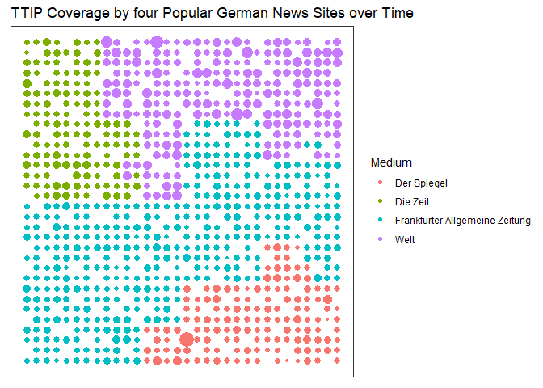

```r
ttip_coverage %>%
    gghilbertplot(
      rank,
      color = medium,
      size = article_nchar,
    ) +
    theme_bw()+
    guides(size = FALSE) +
    theme(
      axis.text.x = element_blank(),
      axis.text.y = element_blank(),
      axis.ticks = element_blank()
    ) +
    scale_x_continuous(breaks = NULL) +
    scale_y_continuous(breaks = NULL) +
    labs(
      title = "TTIP Coverage by four Popular German News Sites over Time",
      x = element_blank(),
      y = element_blank(),
      color = "Medium"
    ) -> ttip_coverage_plot

ttip_coverage_plot
```

The plot can then be animated with the help of the package gganimate. Note that size is mapped to the number of characters in the news media articles and color is mapped to the news media outlet.

```r
# add animations
ttip_coverage_plot +
  transition_time(date) +
  enter_fade() +
  exit_shrink() +
  labs(
    subtitle = "Date: {frame_time}"
  ) -> ttip_coverage_plot
```

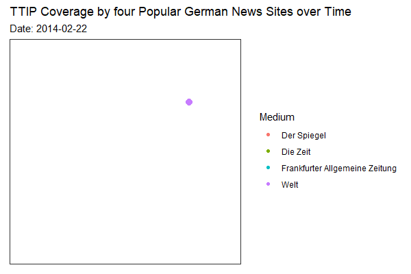

```r
# animate plot
animate(
  ttip_coverage_plot,
  renderer = gifski_renderer(),
  duration = 100,
  fps = 20,
  width = 600,
  height = 400,
  res = 100
)
```